# Model Performance - linear

Hakan Egeli

Soumyendu Sarkar

April 24, 2018

# Exploratory Data Analysis.

## Sales Attributes and Possible Correlations

### Correlation of Sales Summaries and Credit Limit

Since our Naive model was based on **Sales Last Year**, we wanted to see how all the sales summary variables correlated to the **Credit Limit**

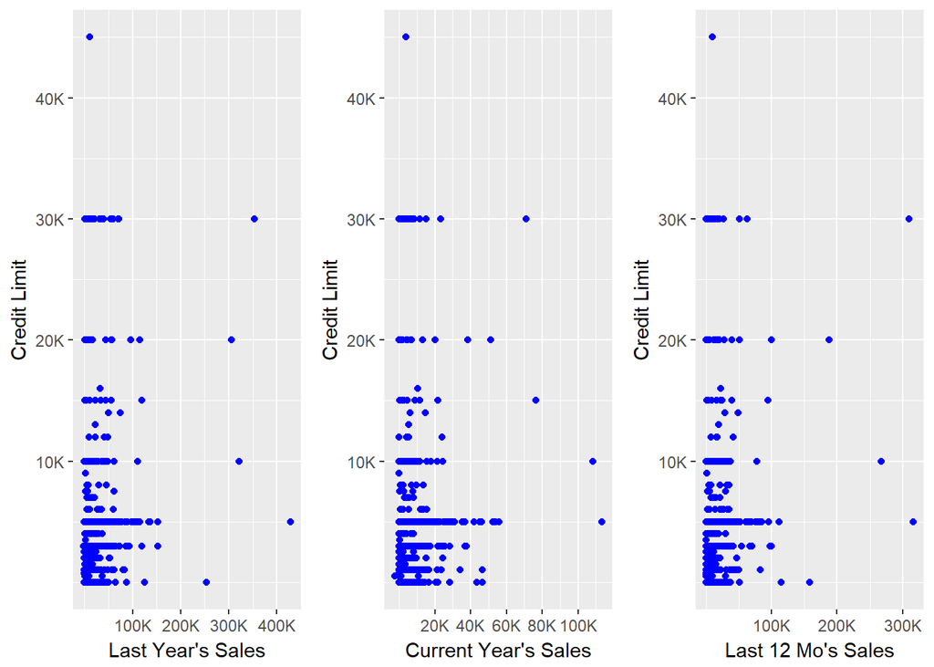

Unfortunately, we did not see a linear correlation between any of the Sales summary variables and the Credit Limit.

### Correlation of 12 Months Sales and Major Product Category Sales

Since the major product category sales for the last 12 months make up majority of the **Last 12 Mo Sales Total** we wanted to examine which product(s) had the most significant correlation.

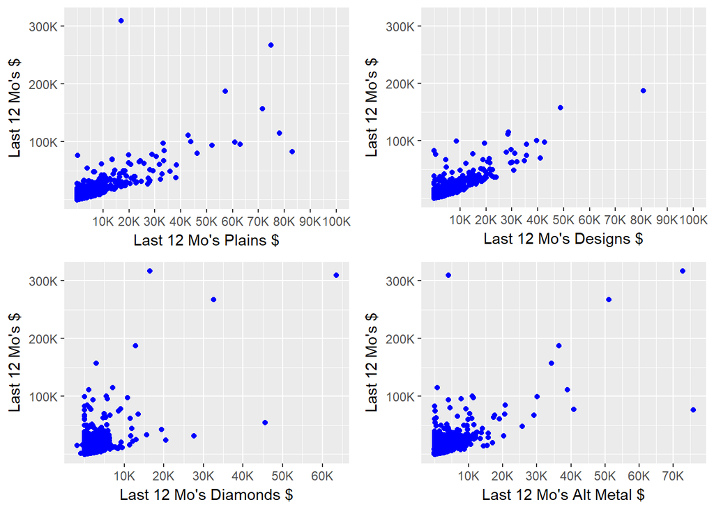

From the scatter plots above, we can see that Plain Bands and Design Bands seem to have the strongest correlation and Diamond Bands and the Alternative Metal Bands have the least.

### Distribution of Credit Limit

We also wanted to understand how the **Credit Limits** were distributed and if the distribution was Gaussian. After plotting a histogram we realized that the Credit Limit distribution was not Gaussian.

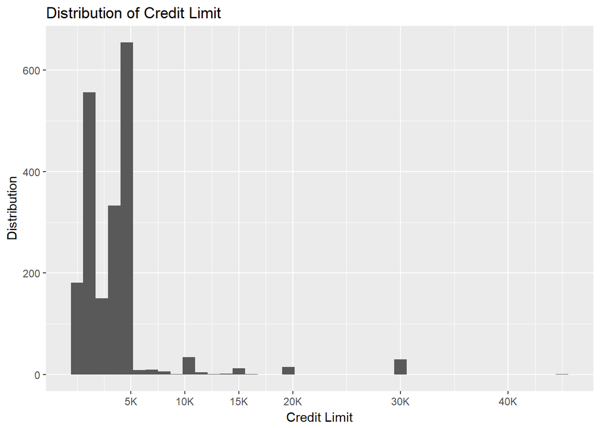

### Relationship Between Avg Days of Pay and Credit Limits

Then we wanted to examine if there was a realtionship between the **Average Days of Pay Categories** and the **Credit Limit**.

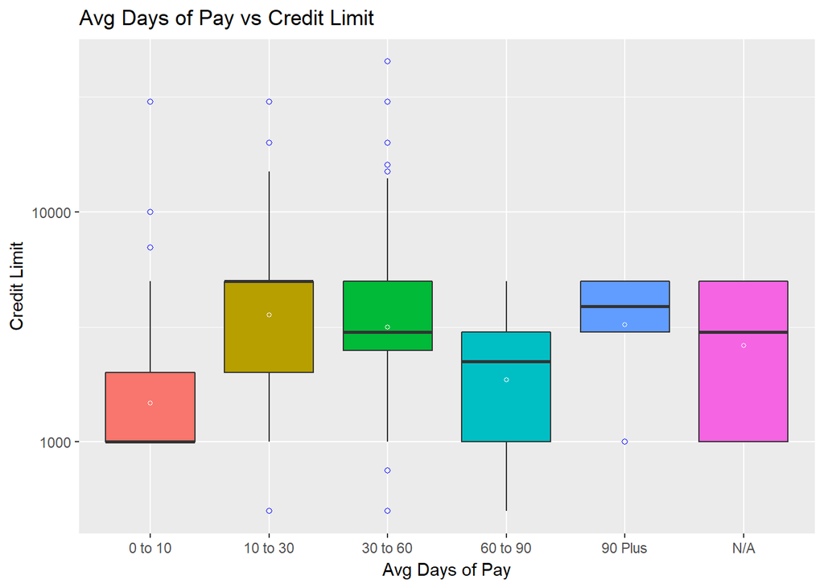

If we remove the Category N/A from the plot, we do see that the means (white circles) do show a possible polynomial relationship. We also wanted to see what the distribution of **Credit Limits** looked like for each of the **Average Days of Pay**.

### Distribution of Credit Limit Among Avg Days of Pay

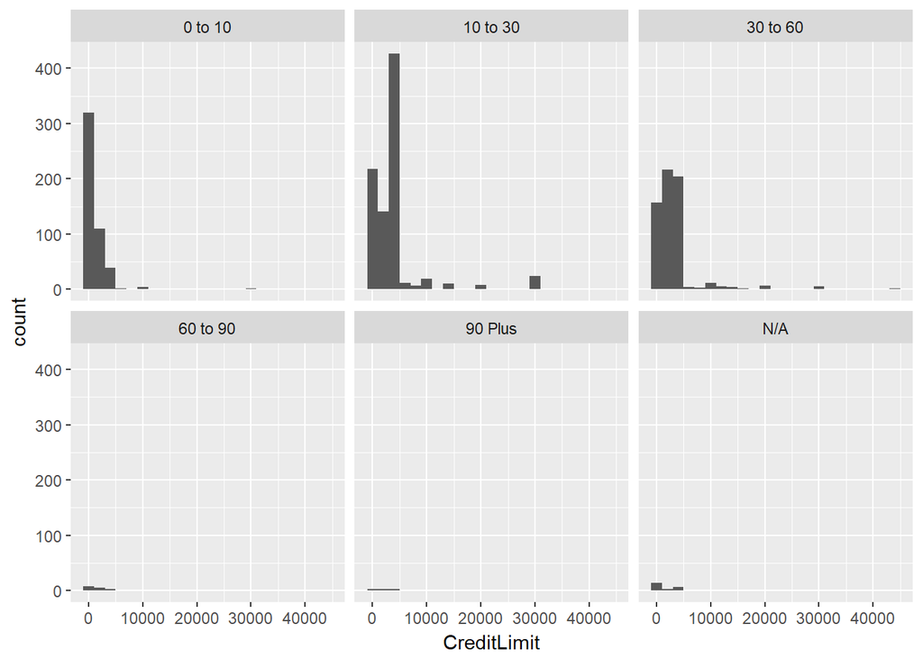

We have examined our dataset for near zero variance parameters and identified the following variables to be near zero:

```
##                       freqRatio percentUnique zeroVar  nzv
## ReturnedPaymentCount     123.75     0.2498751   FALSE TRUE
## MaxReturnedPaymentAmt   1980.00     1.0994503   FALSE TRUE
## NA                           NA            NA      NA   NA
## NA.1                         NA            NA      NA   NA
## NA.2                         NA            NA      NA   NA
```

We have observed that the near zero variance parameters were returns related and We did not further investigate the remaining Returns related variables in our dataset.

## Non-Sales Attributes and Possible Correlations

We enhanced our dataset by bringing in Census data for **Retail Trade: Geographic Area Series: Summary Statistics for the U.S., States, Metro Areas, Counties, and Places**, **Annual Estimates of the Resident Population**, **MEDIAN INCOME IN THE PAST 12 MONTHS (IN 2016 INFLATION-ADJUSTED DOLLARS)**, **TOTAL POPULATION**, and **INDUSTRY BY MEDIAN EARNINGS IN THE PAST 12 MONTHS (IN 2016 INFLATION-ADJUSTED DOLLARS) FOR THE CIVILIAN EMPLOYED POPULATION 16 YEARS AND OVER** and mapped these values to our customer records via StateFIPS, CountyFIPS and CBSA Codes (for metro areas).

### Avg Days of Pay and Median Household Income

We wanted to see if there was a correlation between the Average Days of Pay and Median Household Income where the stores are located and we did see that the first three categories had very similar patterns of Median Income distribution.

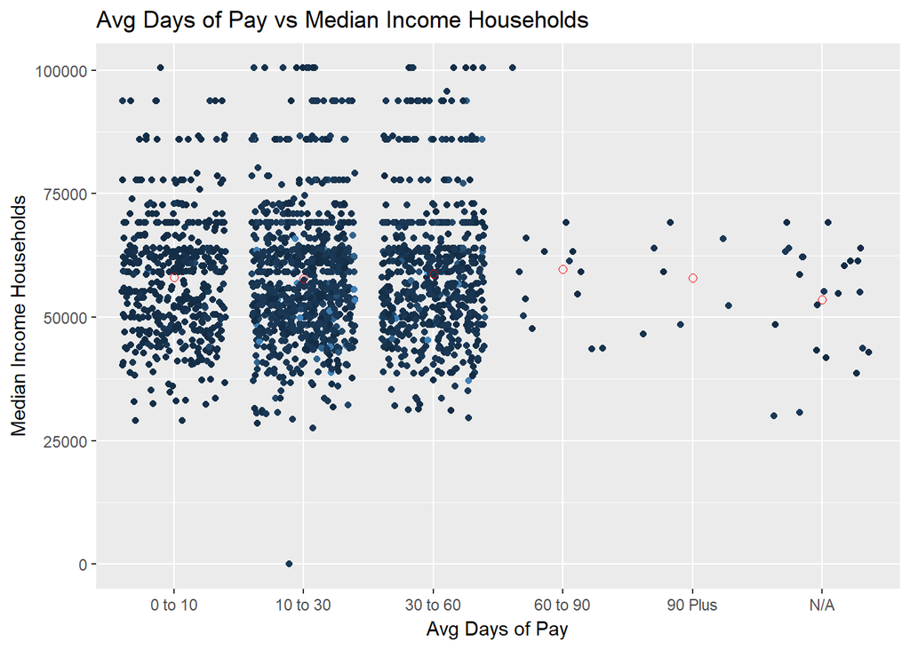

And finally we wanted to examine if there was any kind of correlation between the ** Total Sales Last 12 Mos** and the **Urban Influence**. Urban Influence is an indicator which describes a statistical area whether it is a Major Metro Area, Micro Metro Area, Micro Metro Adjesent to a Major Metro Area, or more Rural.

Additionally, we have examined the correlation between the **Total Population** and the **Number of Jewelry Stores** (via the NAICS Code 4483 - Jewelry Stores) associated with that customer’s location.

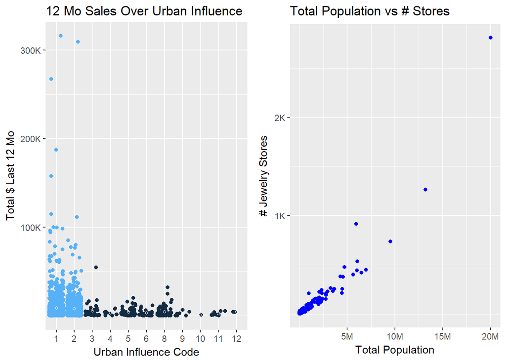

We did see that the larger Metro and Micro areas (light blue, Urban Influence Codes 1 and 2) did have customers with higher **Total SalesLast 12 Mos** and as the **Urban Influence** moved towards rural the total sales significantly became lower. Additionally, we saw a significant correlation between the **Total Population** and the **Number of Stores** from out dataset.

# Build a Linear Model

Using all the variables (except JBT Rating), we examined revelance of the variables in our dataset. The reason we exluded the JBT Rating is because we want to be able to make predictions for the new customers who do not have a Credit Rating, so we did not want this variable to play a role in our model.

```
##
## Call:
## lm(formula = CreditLimit ~ SalesCurrentYr + SalesLastYr + PlainBandSalesLast12Mo +
##     DesignBandSalesLast12Mo + DiamondBandSalesLast12Mo + AlternativeMetalSalesLast12Mo +
##     TotalSalesLast12Mo + BuyingGroupMember + NumberOfStoreLocations +
##     AvgDaysOfPayCategory + AvgDaysOfPay + MaxDaysPastDue + MaxAmtPastDue +
##     AvgAmtPastDue + ReturnedPaymentCount + MaxReturnedPaymentAmt +
##     RuralUrbanContinuumCode + UrbanInfluenceCode + MetroIndicator +
##     TotalPopulation + MedianEarnings + MedianRetailTradeEarnings +
##     TotalHouseholds + MedianIncomeHouseholds + NumberOfJewelryStores +
##     NumberOfJewelryStoresState + JewelryStoreSalesState, data = dataset_train)
##
## Residuals:
##    Min     1Q Median     3Q    Max
## -15407  -1814   -421    778  41130
##
## Coefficients:
##                                 Estimate Std. Error t value Pr(>|t|)
## (Intercept)                   -3.381e-02  1.877e+03   0.000  0.99999
## SalesCurrentYr                -7.631e-02  3.322e-02  -2.297  0.02179 *
## SalesLastYr                    2.785e-02  1.776e-02   1.568  0.11704
## PlainBandSalesLast12Mo         5.400e+01  2.308e+02   0.234  0.81508
## DesignBandSalesLast12Mo        5.406e+01  2.308e+02   0.234  0.81489
## DiamondBandSalesLast12Mo       5.399e+01  2.308e+02   0.234  0.81510
## AlternativeMetalSalesLast12Mo  5.396e+01  2.308e+02   0.234  0.81521
## TotalSalesLast12Mo            -5.397e+01  2.308e+02  -0.234  0.81517
## BuyingGroupMember             -3.226e+02  3.186e+02  -1.013  0.31147
## NumberOfStoreLocations         2.170e+02  1.943e+02   1.117  0.26427
## AvgDaysOfPayCategory10 to 30   2.476e+03  4.183e+02   5.919 4.13e-09 ***
## AvgDaysOfPayCategory30 to 60   1.448e+03  6.855e+02   2.112  0.03490 *
## AvgDaysOfPayCategory60 to 90  -5.952e+02  1.772e+03  -0.336  0.73694
## AvgDaysOfPayCategory90 Plus    1.397e+02  3.582e+03   0.039  0.96889
## AvgDaysOfPayCategoryN/A        2.997e+02  1.743e+03   0.172  0.86350
## AvgDaysOfPay                   9.489e+00  1.928e+01   0.492  0.62262
## MaxDaysPastDue                -1.206e+00  3.864e+00  -0.312  0.75512
## MaxAmtPastDue                 -7.204e-03  8.159e-02  -0.088  0.92965
## AvgAmtPastDue                 -1.252e-01  2.548e-01  -0.492  0.62315
## ReturnedPaymentCount          -6.731e+02  9.090e+02  -0.740  0.45916
## MaxReturnedPaymentAmt         -3.443e-01  8.879e-01  -0.388  0.69822
## RuralUrbanContinuumCode        3.349e+02  2.591e+02   1.293  0.19640
## UrbanInfluenceCode             7.284e+01  2.164e+02   0.337  0.73651
## MetroIndicator                 1.394e+03  8.489e+02   1.642  0.10091
## TotalPopulation               -3.675e-05  6.677e-04  -0.055  0.95612
## MedianEarnings                 1.508e-01  7.143e-02   2.111  0.03493 *
## MedianRetailTradeEarnings     -5.246e-02  5.675e-02  -0.924  0.35549
## TotalHouseholds                1.016e-04  1.992e-03   0.051  0.95932
## MedianIncomeHouseholds        -8.119e-02  3.021e-02  -2.688  0.00728 **
## NumberOfJewelryStores         -1.781e-01  8.216e-01  -0.217  0.82845
## NumberOfJewelryStoresState    -5.298e-01  1.169e+00  -0.453  0.65043
## JewelryStoreSalesState         3.990e-04  8.019e-04   0.498  0.61890
## ---
## Signif. codes:  0 '***' 0.001 '**' 0.01 '*' 0.05 '.' 0.1 ' ' 1
##
## Residual standard error: 4190 on 1308 degrees of freedom
##   (61 observations deleted due to missingness)
## Multiple R-squared:  0.1405, Adjusted R-squared:  0.1201
## F-statistic: 6.896 on 31 and 1308 DF,  p-value: < 2.2e-16
```

After viewing the summary and looking at the significance of the coefficients we notice tha the coefficient with the highest P value is the intercept.

### Remove the intercept

```
##
## Call:
## lm(formula = CreditLimit ~ 1 + SalesCurrentYr + SalesLastYr +
##     PlainBandSalesLast12Mo + DesignBandSalesLast12Mo + DiamondBandSalesLast12Mo +
##     AlternativeMetalSalesLast12Mo + TotalSalesLast12Mo + BuyingGroupMember +
##     NumberOfStoreLocations + AvgDaysOfPayCategory + AvgDaysOfPay +
##     MaxDaysPastDue + MaxAmtPastDue + AvgAmtPastDue + ReturnedPaymentCount +
##     MaxReturnedPaymentAmt + RuralUrbanContinuumCode + UrbanInfluenceCode +
##     MetroIndicator + TotalPopulation + MedianEarnings + MedianRetailTradeEarnings +
##     TotalHouseholds + MedianIncomeHouseholds + NumberOfJewelryStores +
##     NumberOfJewelryStoresState + JewelryStoreSalesState - 1,
##     data = dataset_train)
##
## Residuals:
##    Min     1Q Median     3Q    Max
## -15407  -1814   -421    778  41130
##
## Coefficients:
##                                 Estimate Std. Error t value Pr(>|t|)
## SalesCurrentYr                -7.631e-02  3.322e-02  -2.297  0.02179 *
## SalesLastYr                    2.785e-02  1.776e-02   1.568  0.11704
## PlainBandSalesLast12Mo         5.400e+01  2.308e+02   0.234  0.81508
## DesignBandSalesLast12Mo        5.406e+01  2.308e+02   0.234  0.81489
## DiamondBandSalesLast12Mo       5.399e+01  2.308e+02   0.234  0.81510
## AlternativeMetalSalesLast12Mo  5.396e+01  2.308e+02   0.234  0.81521
## TotalSalesLast12Mo            -5.397e+01  2.308e+02  -0.234  0.81517
## BuyingGroupMember             -3.226e+02  3.186e+02  -1.013  0.31147
## NumberOfStoreLocations         2.170e+02  1.943e+02   1.117  0.26427
## AvgDaysOfPayCategory0 to 10   -3.381e-02  1.877e+03   0.000  0.99999
## AvgDaysOfPayCategory10 to 30   2.476e+03  1.909e+03   1.297  0.19481
## AvgDaysOfPayCategory30 to 60   1.448e+03  1.990e+03   0.727  0.46712
## AvgDaysOfPayCategory60 to 90  -5.952e+02  2.569e+03  -0.232  0.81680
## AvgDaysOfPayCategory90 Plus    1.397e+02  4.038e+03   0.035  0.97241
## AvgDaysOfPayCategoryN/A        2.997e+02  2.579e+03   0.116  0.90749
## AvgDaysOfPay                   9.489e+00  1.928e+01   0.492  0.62262
## MaxDaysPastDue                -1.206e+00  3.864e+00  -0.312  0.75512
## MaxAmtPastDue                 -7.204e-03  8.159e-02  -0.088  0.92965
## AvgAmtPastDue                 -1.252e-01  2.548e-01  -0.492  0.62315
## ReturnedPaymentCount          -6.731e+02  9.090e+02  -0.740  0.45916
## MaxReturnedPaymentAmt         -3.443e-01  8.879e-01  -0.388  0.69822
## RuralUrbanContinuumCode        3.349e+02  2.591e+02   1.293  0.19640
## UrbanInfluenceCode             7.284e+01  2.164e+02   0.337  0.73651
## MetroIndicator                 1.394e+03  8.489e+02   1.642  0.10091
## TotalPopulation               -3.675e-05  6.677e-04  -0.055  0.95612
## MedianEarnings                 1.508e-01  7.143e-02   2.111  0.03493 *
## MedianRetailTradeEarnings     -5.246e-02  5.675e-02  -0.924  0.35549
## TotalHouseholds                1.016e-04  1.992e-03   0.051  0.95932
## MedianIncomeHouseholds        -8.119e-02  3.021e-02  -2.688  0.00728 **
## NumberOfJewelryStores         -1.781e-01  8.216e-01  -0.217  0.82845
## NumberOfJewelryStoresState    -5.298e-01  1.169e+00  -0.453  0.65043
## JewelryStoreSalesState         3.990e-04  8.019e-04   0.498  0.61890
## ---
## Signif. codes:  0 '***' 0.001 '**' 0.01 '*' 0.05 '.' 0.1 ' ' 1
##
## Residual standard error: 4190 on 1308 degrees of freedom
##   (61 observations deleted due to missingness)
## Multiple R-squared:  0.4831, Adjusted R-squared:  0.4704
## F-statistic:  38.2 on 32 and 1308 DF,  p-value: < 2.2e-16
```

Using **Backward Elimitaion**, we started going through the list of coefficients and removed the largest value coefficient one at a time and re-ran the model and the model summary.

### Backward Elimitaion to find the significant coefficients

```
##    Iterations                               Action RSqrAdjValues
## 1           1                        All Variables        0.1201
## 2           2                     Remove intercept        0.4704
## 3           3          Remove AvgDaysOfPayCategory        0.4455
## 4           4             Add AvgDaysOfPayCategory        0.4704
## 5           5               Remove TotalHouseholds        0.4708
## 6           6              Removed TotalPopulation        0.4713
## 7           7                 Remove MaxAmtPastDue        0.4717
## 8           8 Remove AlternativeMetalSalesLast12Mo        0.4720
## 9           9            Remove TotalSalesLast12Mo        0.4724
## 10         10            Remove UrbanInfluenceCode        0.4728
## 11         11                Remove MaxDaysPastDue        0.4731
## 12         12      Remove DiamondBandSalesLast12Mo        0.4735
## 13         13         Remove MaxReturnedPaymentAmt        0.4738
## 14         14                  Remove AvgDaysOfPay        0.4740
## 15         15    Remove NumberOfJewelryStoresState        0.4743
## 16         16        Remove JewelryStoreSalesState        0.4746
## 17         17                 Remove AvgAmtPastDue        0.4749
## 18         18     Remove MedianRetailTradeEarnings        0.4750
## 19         19        Remove PlainBandSalesLast12Mo        0.4751
## 20         20         Remove NumberOfJewelryStores        0.4774
## 21         21             Remove BuyingGroupMember        0.4776
## 22         22          Remove ReturnedPaymentCount        0.4774
```

Our final linear model became the following after our **Backward Elimitaion** process:

```r
model <- lm(formula = CreditLimit ~ SalesCurrentYr + SalesLastYr + DesignBandSalesLast12Mo + NumberOfStoreLocations + AvgDaysOfPayCategory + ReturnedPaymentCount + RuralUrbanContinuumCode + MetroIndicator + MedianEarnings + MedianIncomeHouseholds - 1, data = dataset_train)

summary(model)
```

```
##
## Call:
## lm(formula = CreditLimit ~ SalesCurrentYr + SalesLastYr + DesignBandSalesLast12Mo +
##     NumberOfStoreLocations + AvgDaysOfPayCategory + ReturnedPaymentCount +
##     RuralUrbanContinuumCode + MetroIndicator + MedianEarnings +
##     MedianIncomeHouseholds - 1, data = dataset_train)
##
## Residuals:
##    Min     1Q Median     3Q    Max
## -15074  -1813   -378    760  41173
##
## Coefficients:
##                                Estimate Std. Error t value Pr(>|t|)
## SalesCurrentYr                 -0.06470    0.02836  -2.281 0.022696 *
## SalesLastYr                     0.02717    0.01089   2.496 0.012671 *
## DesignBandSalesLast12Mo         0.08893    0.02512   3.540 0.000413 ***
## NumberOfStoreLocations        210.95860  167.07726   1.263 0.206931
## AvgDaysOfPayCategory0 to 10  -187.86247 1355.78843  -0.139 0.889815
## AvgDaysOfPayCategory10 to 30 2467.39658 1355.55975   1.820 0.068943 .
## AvgDaysOfPayCategory30 to 60 1501.70599 1367.53405   1.098 0.272346
## AvgDaysOfPayCategory60 to 90   36.43143 1815.67106   0.020 0.983994
## AvgDaysOfPayCategory90 Plus  1092.27475 2453.54635   0.445 0.656258
## AvgDaysOfPayCategoryN/A      -287.54572 1652.27230  -0.174 0.861867
## ReturnedPaymentCount         -860.47208  726.35284  -1.185 0.236360
## RuralUrbanContinuumCode       325.63329  157.00803   2.074 0.038264 *
## MetroIndicator               1195.84935  684.36553   1.747 0.080792 .
## MedianEarnings                  0.10008    0.05015   1.996 0.046178 *
## MedianIncomeHouseholds         -0.06454    0.02308  -2.797 0.005235 **
## ---
## Signif. codes:  0 '***' 0.001 '**' 0.01 '*' 0.05 '.' 0.1 ' ' 1
##
## Residual standard error: 4124 on 1386 degrees of freedom
## Multiple R-squared:  0.4832, Adjusted R-squared:  0.4776
## F-statistic: 86.39 on 15 and 1386 DF,  p-value: < 2.2e-16
```

```r
predictions <- predict(model, dataset_train)

summary(predictions)
```

```
##    Min. 1st Qu.  Median    Mean 3rd Qu.    Max.
##  -272.5  2627.6  3806.7  3615.5  4475.6 29580.2
```

We calculated the $RMSE$ value for our **Training Set** predictions:

```
## Root Mean Square Error:  4102.183
```

The $RMSE$ for our **Naive Model’s** training set was 4312.198. So it looks like our new model improved slightly for our training set values.

Using our **Test Set**, we obtained a new set of predictions and calculated the $RMSE$ value for our test predictions:

```
## Root Mean Square Error:  4151.626
```

The $RMSE$ for our **Naive Model’s** test set was 4106.185. Based on these $RMSE$ values, our new model did not improve for our test set!

# Build a linear model #2.a

We came back to our linear model after we built our Decision-Tree model to see if we can build a similar linear model and if that would perform better. Using the same relevant variables which we have used in our decision tree as a start, and going through the Backward Elimination process, we came up with the following model:

```
##
## Call:
## lm(formula = CreditLimit ~ DesignBandSalesLast12Mo + AvgDaysOfPay +
##     SalesLastYr + TotalSalesLast12Mo + AlternativeMetalSalesLast12Mo +
##     MedianIncomeHouseholds + SalesCurrentYr + PlainBandSalesLast12Mo +
##     MedianEarnings + RuralUrbanContinuumCode, data = dataset_train)
##
## Residuals:
##    Min     1Q Median     3Q    Max
## -15332  -2091   -961   1283  40387
##
## Coefficients:
##                                 Estimate Std. Error t value Pr(>|t|)
## (Intercept)                    3.077e+03  9.441e+02   3.259  0.00114 **
## DesignBandSalesLast12Mo        9.949e-02  7.590e-02   1.311  0.19015
## AvgDaysOfPay                   2.318e+01  7.322e+00   3.166  0.00158 **
## SalesLastYr                    2.213e-02  1.621e-02   1.365  0.17255
## TotalSalesLast12Mo            -1.182e-03  6.100e-02  -0.019  0.98455
## AlternativeMetalSalesLast12Mo  7.416e-03  6.766e-02   0.110  0.91274
## MedianIncomeHouseholds        -6.580e-02  2.389e-02  -2.755  0.00596 **
## SalesCurrentYr                -7.369e-02  3.271e-02  -2.253  0.02441 *
## PlainBandSalesLast12Mo         3.669e-02  6.063e-02   0.605  0.54514
## MedianEarnings                 9.057e-02  5.160e-02   1.755  0.07945 .
## RuralUrbanContinuumCode        1.136e+02  8.727e+01   1.302  0.19329
## ---
## Signif. codes:  0 '***' 0.001 '**' 0.01 '*' 0.05 '.' 0.1 ' ' 1
##
## Residual standard error: 4254 on 1379 degrees of freedom
##   (11 observations deleted due to missingness)
## Multiple R-squared:  0.08277,    Adjusted R-squared:  0.07612
## F-statistic: 12.44 on 10 and 1379 DF,  p-value: < 2.2e-16
```

The $R^2 Adjusted$ value for this model was **significantly lower** than the model we came up with earlier!

# Build a linear model #2.b

We also wanted to examine if we could build a better linear model using non-sales variables. We started with all non-sales related variables which we have obtained from census.gov and went through the backward elimination and removed the least significant coefficient until we have reached an $R^2 Adjusted$ value which did not improve any further.

```
##
## Call:
## lm(formula = CreditLimit ~ RuralUrbanContinuumCode + MetroIndicator +
##     MedianEarnings + MedianIncomeHouseholds + NumberOfJewelryStores -
##     1, data = dataset_train)
##
## Residuals:
##    Min     1Q Median     3Q    Max
##  -5101  -2364   -764   1235  41574
##
## Coefficients:
##                           Estimate Std. Error t value Pr(>|t|)
## RuralUrbanContinuumCode  528.27022  104.41821   5.059 4.79e-07 ***
## MetroIndicator          1908.04216  512.31221   3.724 0.000204 ***
## MedianEarnings             0.15597    0.04825   3.232 0.001258 **
## MedianIncomeHouseholds    -0.07672    0.02508  -3.059 0.002267 **
## NumberOfJewelryStores     -0.31078    0.18367  -1.692 0.090868 .
## ---
## Signif. codes:  0 '***' 0.001 '**' 0.01 '*' 0.05 '.' 0.1 ' ' 1
##
## Residual standard error: 4425 on 1346 degrees of freedom
##   (50 observations deleted due to missingness)
## Multiple R-squared:  0.4075, Adjusted R-squared:  0.4053
## F-statistic: 185.2 on 5 and 1346 DF,  p-value: < 2.2e-16
```

This one was significantly better than the one we came up with using the variables from the Decision Tree model and our original **Naive** model, but it wasn’t better than the one we developed using the Backward Elimination at the top of our analysis.

# Build Generalized Linear Model

We wanted to test and try different “family” parameters and other optimization parameters in our next iterations so we decided to verify if the results of the `lm()` function and the `glm()` function matched.

```
##
## Call:
## glm(formula = CreditLimit ~ SalesCurrentYr + SalesLastYr + DesignBandSalesLast12Mo +
##     NumberOfStoreLocations + AvgDaysOfPayCategory + ReturnedPaymentCount +
##     RuralUrbanContinuumCode + MetroIndicator + MedianEarnings +
##     MedianIncomeHouseholds - 1, family = gaussian, data = dataset_train)
##
## Deviance Residuals:
##    Min      1Q  Median      3Q     Max
## -15074   -1813    -378     760   41173
##
## Coefficients:
##                                Estimate Std. Error t value Pr(>|t|)
## SalesCurrentYr                 -0.06470    0.02836  -2.281 0.022696 *
## SalesLastYr                     0.02717    0.01089   2.496 0.012671 *
## DesignBandSalesLast12Mo         0.08893    0.02512   3.540 0.000413 ***
## NumberOfStoreLocations        210.95860  167.07726   1.263 0.206931
## AvgDaysOfPayCategory0 to 10  -187.86247 1355.78843  -0.139 0.889815
## AvgDaysOfPayCategory10 to 30 2467.39658 1355.55975   1.820 0.068943 .
## AvgDaysOfPayCategory30 to 60 1501.70599 1367.53405   1.098 0.272346
## AvgDaysOfPayCategory60 to 90   36.43143 1815.67106   0.020 0.983994
## AvgDaysOfPayCategory90 Plus  1092.27475 2453.54635   0.445 0.656258
## AvgDaysOfPayCategoryN/A      -287.54572 1652.27230  -0.174 0.861867
## ReturnedPaymentCount         -860.47208  726.35284  -1.185 0.236360
## RuralUrbanContinuumCode       325.63329  157.00803   2.074 0.038264 *
## MetroIndicator               1195.84935  684.36553   1.747 0.080792 .
## MedianEarnings                  0.10008    0.05015   1.996 0.046178 *
## MedianIncomeHouseholds         -0.06454    0.02308  -2.797 0.005235 **
## ---
## Signif. codes:  0 '***' 0.001 '**' 0.01 '*' 0.05 '.' 0.1 ' ' 1
##
## (Dispersion parameter for gaussian family taken to be 17010027)
##
##     Null deviance: 4.5618e+10  on 1401  degrees of freedom
## Residual deviance: 2.3576e+10  on 1386  degrees of freedom
## AIC: 27318
##
## Number of Fisher Scoring iterations: 2
```

```
##    Min. 1st Qu.  Median    Mean 3rd Qu.    Max.
##  -272.5  2627.6  3806.7  3615.5  4475.6 29580.2
```